# A Lesson in Slow Stats: ISU Professor Salaries

Gina Nichols

11/27/2020

# Slow stats

Largely in response to the proliferation of 🍔 fast food 🍟, wherein you can obtain a fully cooked meal in less than 5 minutes from a fast food establishment, a 🐮 slow food 🥔 movement was born. A tenant of the slow food movement is to recognize the cultural traditions and knowledge surrounding the production, cooking, and consuming of the food.

Here I apply this framework to statistics. I explore a dataset (ISU Professor Salaries) using fast stats, and slow stats.

## The dataset: ISU professor salaries and gender disparities

### Access

I’ve loaded my tidyverse packages already. I have a package with the salary data on my github page. We will use the *professors* dataset.

```r
if("CyChecks3" %in% rownames(installed.packages()) == FALSE) {remotes::install_github("vanichols/CyChecks3")}
library(CyChecks3)

data("professors")
profs <- professors %>% as_tibble()
head(profs) %>%
  knitr::kable()
```

| year | college | dept | gender | name | title | title_simp | rank | dept_chair | base_salary | travel_subsistence | total_salary_paid | base50 |
| --- | --- | --- | --- | --- | --- | --- | --- | --- | --- | --- | --- | --- |
| 2019 | college of engineering | aerospace eng | m | abdelkhalik ossama o | assoc prof | assoc prof | assoc | N | 119180 | 4519.22 | 124555.56 | Y |
| 2019 | college of agriculture & life sciences | food sc/hn | f | acevedo nuria cristi | asst prof | asst prof | asst | N | 85095 | 745.14 | 85991.00 | Y |
| 2019 | college of liberal arts & sciences | eeob | m | adams dean | prof | prof | prof | N | 110872 | 7638.81 | 146865.42 | Y |
| 2019 | college of design | architecture | m | adams ross exo | asst prof | asst prof | asst | N | 0 | 2457.65 | 80744.00 | N |
| 2019 | college of agriculture & life sciences | nat res ecl/mgt | m | adelman james stephe | asst prof | asst prof | asst | N | 0 | 1080.78 | 79772.77 | N |
| 2019 | college of liberal arts & sciences | computer sc | m | aduri pavankumar r | prof | prof | prof | N | 110904 | 4268.20 | 117054.52 | Y |

### Wrangling

Our question is whether male and females have different salaries. Maybe this is cheating, but I think it’s important to QC it.

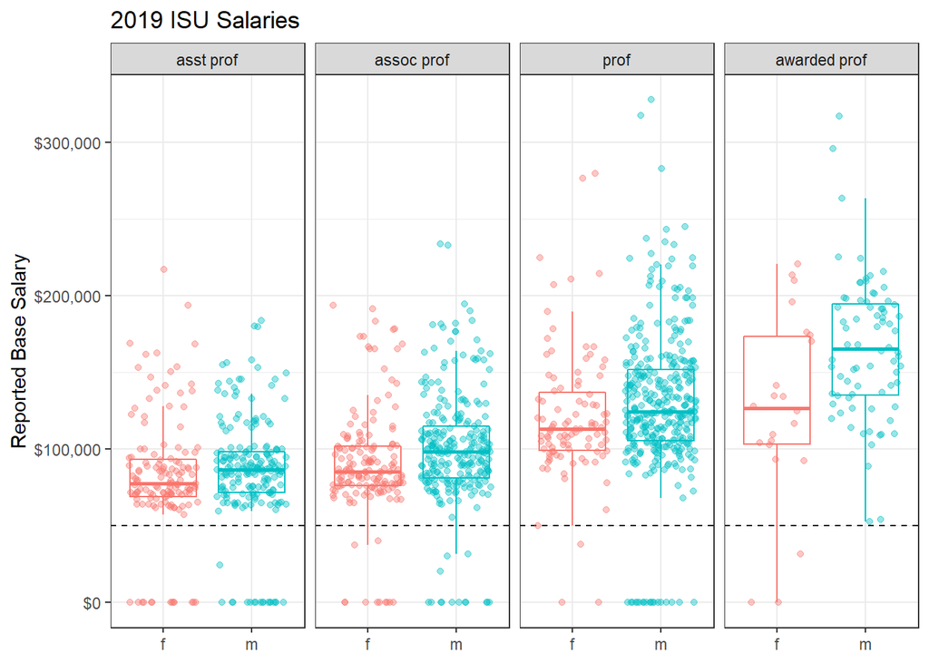

```r
profs %>%
  mutate(title_simp = as_factor(title_simp),
         title_simp = fct_reorder(title_simp, base_salary)) %>%
  ggplot(aes(gender, base_salary, color = gender)) +
  geom_boxplot(outlier.colour = NA) +
  geom_hline(yintercept = 50000, linetype = "dashed") +
  geom_jitter(alpha = 0.4) +
  facet_grid(.~title_simp) +
  scale_y_continuous(labels = dollar_format()) +
  guides(color = F) +
  labs(title = "2019 ISU Salaries",
       y = "Reported Base Salary",
       x = NULL)
```

Also, dang. Who makes more than $150K as an Asst Prof? 💸

```r
profs %>%
  filter(base_salary > 150000,
         title_simp == "asst prof") %>%
  select(college, dept, title) %>%
  distinct() %>%
  knitr::kable()
```

| college | dept | title |
| --- | --- | --- |
| college of business | management | asst prof |
| college of business | marketing | asst prof |
| college of business | finance | asst prof |
| college of business | accounting | asst prof |

Oh. Business people. 😀

Create data for the models (mdat) that doesn’t include people making less than $50K and department heads.

```r
mdat <-
  profs %>%
  filter(dept_chair == "N") %>%
  filter(base50 == "Y")  %>%
  mutate(lsal = log(base_salary)) %>% #--because I'm not sure how brms works
  select(dept, gender, rank, base_salary, lsal) %>%
  mutate_if(is.character, as.factor)
```

## Fast stats 🍟

I can shove this dataset through a frequentist model without even thinking about it.

```r
library(lme4)
library(emmeans)
library(broom)
library(tidytext) #--for reordering within a group
```

My queston is whether males and females have different salaries. We only have one year of clean data right now, so the main variables to consider include:

1. Gender
2. Professor rank
3. Department

*Gender*

I am not interested in the population of males and females, I’m interested in the males and females at Iowa State University. So this is a fixed effect.

*Professor rank*

Some professors were hired in…1980? Maybe even before. It may be that women were paid less if they were hired in the 1980s, and that lower salary has followed them. Assistant professors were likey hired within the last 5-6 years, so hopefully there aren’t any salary differences in that hiring timeframe. It therefore makes sense to look at each ‘professor rank’ separately, as a fixed effect.

*Department*

This one is tricky, and depends on the question. While I may want to know if, overall, female professors are paid less than male professors (treat departments like a sample from a population, a random effect), if one wants to do an intervention it should likely happen on a department level (treat departments as a unit of interest, a fixed effect).

As per our conversation with Fernando, I order the explanatory variables in the order I think is strongest to weakest. It shouldn’t matter with *lm*, I believe.

First I’ll see if there is any evidence that, on a university level, there are salary disparities by gender. I’ll allow the intercept to vary by department.

I’m curious if I should also allow the effect of gender to vary by department. I can test that using AIC. Note I have to specify REML = F to compare models.

```r
fme1 <- lmerTest::lmer(lsal ~ rank * gender + (1|dept), data = mdat, REML = F)
fme2 <- lmerTest::lmer(lsal ~ rank * gender + (1 + gender|dept), data = mdat, REML = F)
```

```
## boundary (singular) fit: see ?isSingular
```

```r
anova(fme1, fme2)
```

```
## Data: mdat
## Models:
## fme1: lsal ~ rank * gender + (1 | dept)
## fme2: lsal ~ rank * gender + (1 + gender | dept)
##      npar     AIC     BIC logLik deviance  Chisq Df Pr(>Chisq)
## fme1   10 -950.91 -900.34 485.45  -970.91
## fme2   12 -947.48 -886.80 485.74  -971.48 0.5734  2     0.7508
```

I think the random-slope model is unhappy because there are departments with only one gender. But no matter, it seems the random slope does not improve our model anyways.

I will use the *emmeans* package to compare genders at each rank.

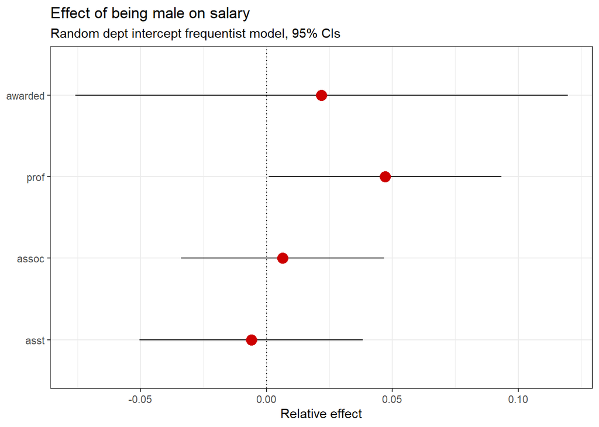

```r
emmeans(fme1, specs = pairwise ~ rank:gender, type = "response")$contrasts %>%
    confint(level = 0.8) %>%
    as_tibble() %>%
  separate(contrast, into = c("x1", "x2"), sep = "-") %>%
  filter(grepl("m", x2)) %>%
   mutate_if(is.character, str_trim) %>%
    mutate(x1prof = str_sub(x1, 1, -3),
           x2prof = str_sub(x2, 1, -3)) %>%
    filter(x1prof == x2prof) %>%
  mutate_if(is.numeric, function(x) (x*-1)) %>%
  mutate(SE = abs(SE),
         x1prof = factor(x1prof, levels = c("asst", "assoc", "prof", "awarded"))) %>%
  ggplot(aes(x1prof, estimate)) +
  geom_hline(yintercept = 0, linetype = "dotted") +
  geom_linerange(aes(ymin = lower.CL, ymax = upper.CL)) +
  geom_point(color = "red3", size = 4) +
  coord_flip() +
  labs(title = "Effect of being male on salary",
       subtitle = "Random dept intercept frequentist model, 95% CIs",
       x = NULL,
       y = "Relative effect")
```

Oooooh it looks like male professors make more than females at Iowa State University. 😮

While this information is interesting, salary decisions are likely made at a department level. So it might be helpful to see if there are specific departments that have large gender-based disparities.

For that I can use a fixed effect model with a 3-way interaction between *rank*, *gender*, and *dept*. I have saved the emmeans comparisons in the package as *cystats*, so I’ll just use that.

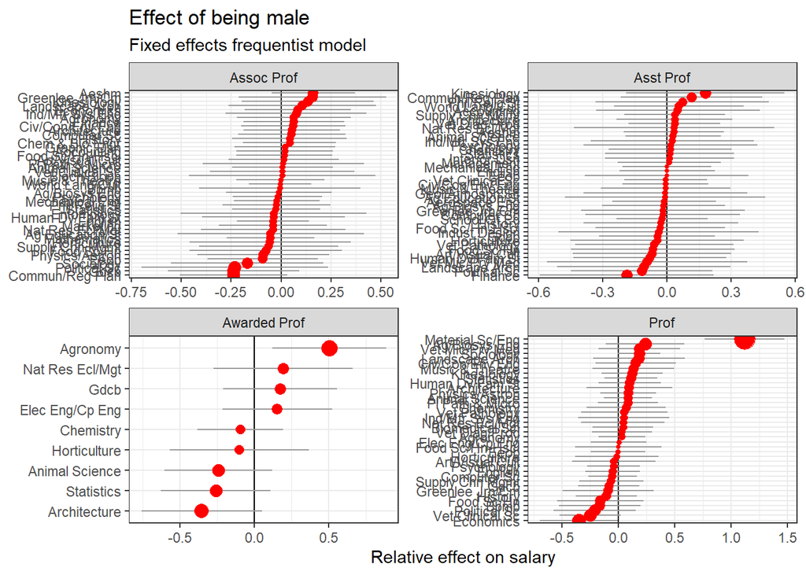

```r
fm1 <- lm(lsal ~ rank * gender * dept, data = mdat)

cystats %>%
  ggplot(aes(dept2, estimate)) +
  geom_hline(yintercept = 0) +
  geom_linerange(aes(ymin = lower.CL, ymax = upper.CL), color = "gray60") +
  geom_point(color = "red", aes(size = abs(estimate))) +
  guides(size = F) +
  scale_x_reordered() +
  facet_wrap(~title_simp, scales = "free") +
  coord_flip() +
  labs(x = NULL,
       y = "Relative effect on salary",
       title = "Effect of being male",
       subtitle = "Fixed effects frequentist model")
```

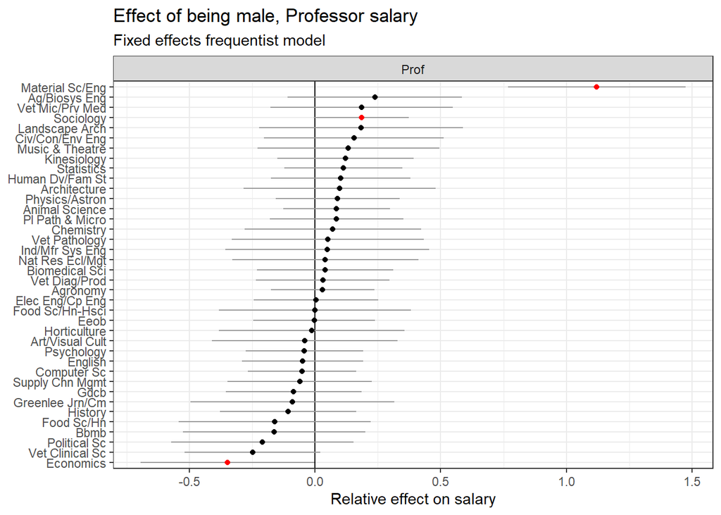

```r
cystats %>%
  filter(title_simp == "Prof") %>%
  mutate(clr = case_when(
    upper.CL > -0.01 ~ "bad",
    lower.CL < 0 ~ "bad",
    TRUE ~ "ok")) %>%
  ggplot(aes(dept2, estimate)) +
  geom_hline(yintercept = 0) +
  geom_linerange(aes(ymin = lower.CL, ymax = upper.CL), color = "gray60") +
  geom_point(aes(color = clr == "bad")) +
  guides(size = F,
         color = F) +
  scale_x_reordered() +
  scale_color_manual(values = c("black", "red")) +
  facet_wrap(~title_simp, scales = "free") +
  coord_flip() +
  labs(x = NULL,
       y = "Relative effect on salary",
       title = "Effect of being male, Professor salary",
       subtitle = "Fixed effects frequentist model")
```

Material Science, Sociology, and Economics may need some attention.

It turns out Material Science has only two women, and one took a half salary in 2019. This is why those values are so disparate. You can explore these things in the [Shiny App](https://vanichols.shinyapps.io/CyChecks2019/) if you are curious.

## Slow stats 🥔 🍳

```r
library(brms)
library(tidybayes)
options(mc.cores = parallel::detectCores())
```

*Priors*

I would guess a rough average salary is ~$120,000. So 11.695247 is a good mean value for the prior on the salaries. A standard deviation of 1 means most salaries are between 4.435610^{4} and 3.2774810^{5}.

I generously assume the effect of position, gender, and their interaction can take a salary from the lowest value to the highest value. It’s likely not that strong, I’m not sure if that matters.

$$\begin{array}{l}
log\_sal_i \sim Normal(\mu_i, \sigma) \\
\mu_i = \alpha + \gamma_i gender_i + \beta_1 pos_i\\
\gamma_i = \beta_2 + \beta_3 pos_i \\
\alpha \sim Normal(11.7, 1) \\
\beta_1, \beta_2, \mathrm{and} \space \beta_3 \sim Normal(0, 1)\\
\sigma \sim Exponential(0,1) \\
\end{array}$$

What do the default priors look like?

```r
get_prior(
  lsal ~  (1 | dept) + rank*gender,
  data = mdat
  )
```

```
##                      prior     class                coef group resp dpar nlpar
## 1                                  b
## 2                                  b             genderm
## 3                                  b            rankasst
## 4                                  b    rankasst:genderm
## 5                                  b         rankawarded
## 6                                  b rankawarded:genderm
## 7                                  b            rankprof
## 8                                  b    rankprof:genderm
## 9  student_t(3, 11.5, 2.5) Intercept
## 10    student_t(3, 0, 2.5)        sd
## 11                                sd                      dept
## 12                                sd           Intercept  dept
## 13    student_t(3, 0, 2.5)     sigma
##    bound
## 1
## 2
## 3
## 4
## 5
## 6
## 7
## 8
## 9
## 10
## 11
## 12
## 13
```

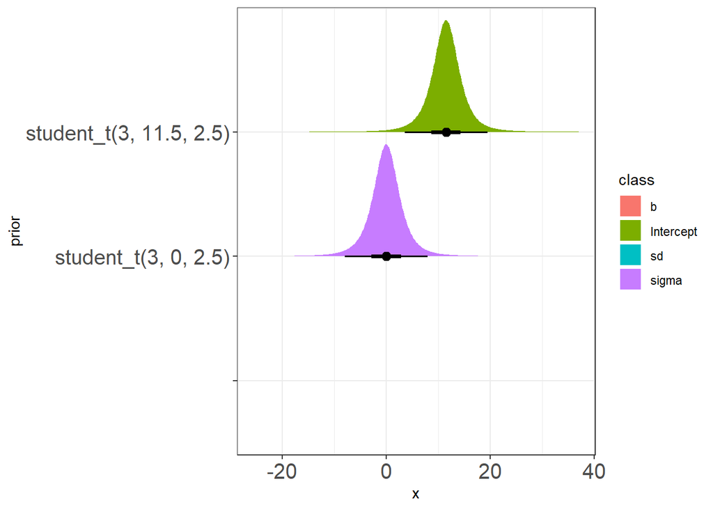

```r
get_prior(
  lsal ~  (1 | dept) + rank*gender,
  data = mdat
  ) %>%
  parse_dist(prior) %>% #--a tidybayes function
  ggplot(aes(y = prior, dist = .dist, args = .args, fill = class)) +
  stat_dist_halfeye() +
  theme(axis.text=element_text(size=15))
```

Visualize them.

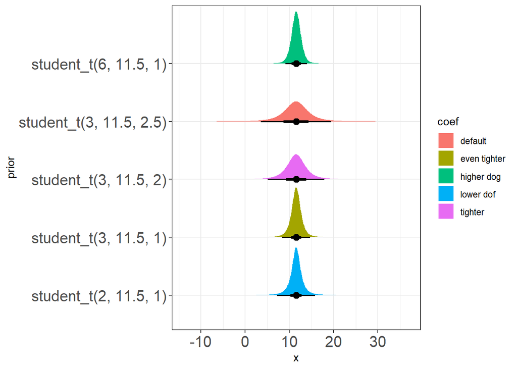

```r
pexp <- prior(student_t(3, 11.5, 2.5), class = "b",  coef = "default") +
  prior(student_t(3, 11.5, 2), class = "b", coef = "tighter") +
  prior(student_t(3, 11.5, 1), class = "b", coef = "even tighter") +
  prior(student_t(2, 11.5, 1), class = "b", coef = "lower dof") +
  prior(student_t(6, 11.5, 1), class = "b", coef = "higher dog")

pexp %>%
  parse_dist(prior) %>% #--a tidybayes function
  ggplot(aes(y = prior, dist = .dist, args = .args, fill = coef)) + #--never would've figured this out
  stat_dist_halfeye() +
  theme(axis.text=element_text(size=15))
```

I think the sd of 1 is reasonable. The right tail should probably be longer.

```r
p0 <-  prior(student_t(6, 11.5, 1), class = "Intercept")

bm0 <-
  brm(
    data = mdat,
    family = gaussian,
    formula = lsal ~ (1|dept) + rank*gender,
    prior = p0,
    iter = 4000, chains = 4,
    seed = 7)
summary(bm0)
```

```
##  Family: gaussian
##   Links: mu = identity; sigma = identity
## Formula: lsal ~ (1 | dept) + rank * gender
##    Data: mdat (Number of observations: 1161)
## Samples: 4 chains, each with iter = 4000; warmup = 2000; thin = 1;
##          total post-warmup samples = 8000
##
## Group-Level Effects:
## ~dept (Number of levels: 59)
##               Estimate Est.Error l-95% CI u-95% CI Rhat Bulk_ESS Tail_ESS
## sd(Intercept)     0.23      0.02     0.19     0.28 1.01      853      989
##
## Population-Level Effects:
##                     Estimate Est.Error l-95% CI u-95% CI Rhat Bulk_ESS Tail_ESS
## Intercept              11.49      0.03    11.43    11.56 1.01      477     1031
## rankasst               -0.11      0.02    -0.14    -0.07 1.00     3132     4301
## rankawarded             0.43      0.04     0.36     0.51 1.00     4191     4626
## rankprof                0.20      0.02     0.16     0.24 1.00     3526     4700
## genderm                 0.01      0.02    -0.03     0.04 1.00     2856     4449
## rankasst:genderm       -0.01      0.02    -0.06     0.04 1.00     3080     4466
## rankawarded:genderm     0.02      0.04    -0.06     0.10 1.00     3749     4482
## rankprof:genderm        0.04      0.02    -0.01     0.09 1.00     2935     4109
##
## Family Specific Parameters:
##       Estimate Est.Error l-95% CI u-95% CI Rhat Bulk_ESS Tail_ESS
## sigma     0.15      0.00     0.14     0.15 1.00     8209     5915
##
## Samples were drawn using sampling(NUTS). For each parameter, Bulk_ESS
## and Tail_ESS are effective sample size measures, and Rhat is the potential
## scale reduction factor on split chains (at convergence, Rhat = 1).
```

Honestly, every time I mess with the priors things get worse. Do it with the defaults.

```r
  bm1 <-
  brm(
    data = mdat,
    family = gaussian,
    formula = lsal ~ (1|dept) + rank*gender,
    iter = 4000, chains = 4,
    seed = 7)
summary(bm1)
```

```
##  Family: gaussian
##   Links: mu = identity; sigma = identity
## Formula: lsal ~ (1 | dept) + rank * gender
##    Data: mdat (Number of observations: 1161)
## Samples: 4 chains, each with iter = 4000; warmup = 2000; thin = 1;
##          total post-warmup samples = 8000
##
## Group-Level Effects:
## ~dept (Number of levels: 59)
##               Estimate Est.Error l-95% CI u-95% CI Rhat Bulk_ESS Tail_ESS
## sd(Intercept)     0.23      0.02     0.19     0.28 1.00      858     1202
##
## Population-Level Effects:
##                     Estimate Est.Error l-95% CI u-95% CI Rhat Bulk_ESS Tail_ESS
## Intercept              11.49      0.03    11.43    11.56 1.00      598     1307
## rankasst               -0.11      0.02    -0.15    -0.07 1.00     4049     5674
## rankawarded             0.43      0.04     0.36     0.51 1.00     4759     4975
## rankprof                0.20      0.02     0.15     0.24 1.00     4023     5215
## genderm                 0.01      0.02    -0.03     0.04 1.00     3595     5495
## rankasst:genderm       -0.01      0.02    -0.06     0.03 1.00     3559     4926
## rankawarded:genderm     0.02      0.04    -0.07     0.10 1.00     4376     5159
## rankprof:genderm        0.04      0.02    -0.01     0.09 1.00     3593     4531
##
## Family Specific Parameters:
##       Estimate Est.Error l-95% CI u-95% CI Rhat Bulk_ESS Tail_ESS
## sigma     0.15      0.00     0.14     0.15 1.00    10057     5667
##
## Samples were drawn using sampling(NUTS). For each parameter, Bulk_ESS
## and Tail_ESS are effective sample size measures, and Rhat is the potential
## scale reduction factor on split chains (at convergence, Rhat = 1).
```

There is no nice emmeans for the brms output, so I actually have to think about what the intercept means.

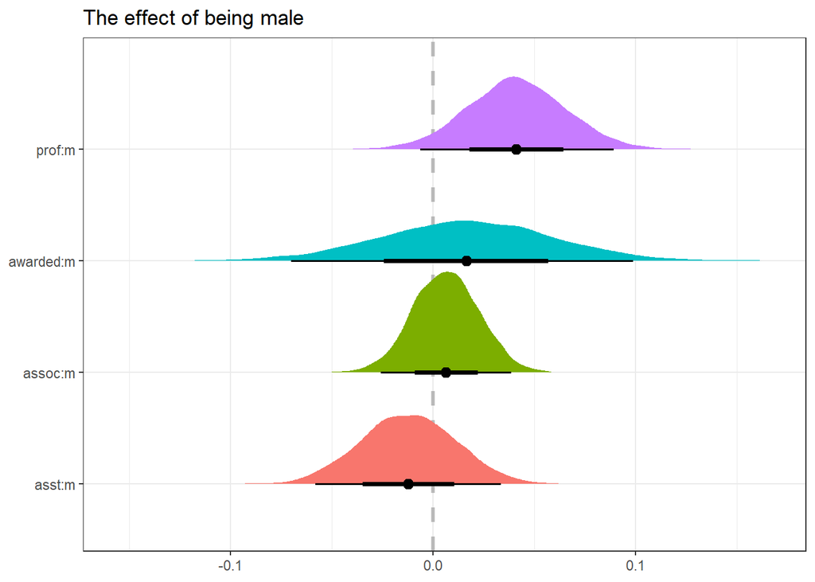

```r
bm1 %>%
  gather_draws(`b_.*`, regex = TRUE) %>%
  ungroup() %>%
  mutate(
    .variable = ifelse(.variable == "b_genderm", "b_rankassoc:genderm", .variable),
    .variable = str_remove_all(.variable, "b_|gender|rank")) %>%
  dplyr::filter(grepl("m", .variable)) %>%
  mutate(.variable = fct_reorder(.variable, .value)) %>%
  ggplot(aes(x = .value, y = .variable)) +
  geom_vline(xintercept = 0, color = "gray50", size = 1.2, lty = 2, alpha = 0.5) +
  geom_halfeyeh(aes(fill = .variable)) +
  theme(legend.position = "none") +
  labs(title = "The effect of being male",
       x = NULL,
       y = NULL)
```

It seems like if I were to ask you if you wanted a male or female salary at the prof rank, you’d tend towards picking the male one.

I tried to run a three-way interaction in brms. It took over an hour. Additionally, doing the gymnastics of getting estimates for each department would have been challenging.